# Linear Regression II

Xiaojing Dong

September 28, 2017

By now, we have some good understanding regarding what we’ve got from running a linear regression model, in terms of the statistical outputs. Let’s get back to the regression model we analyzed, and see how we could improve it.

```r
df = read.csv("Coffee_inClass.csv", header=TRUE)
lm1 = lm(df$Sales1~df$Price1)
summary(lm1)
```

```
##
## Call:
## lm(formula = df$Sales1 ~ df$Price1)
##
## Residuals:
##     Min      1Q  Median      3Q     Max
## -3384.1 -1714.1  -663.7   850.7  8437.7
##
## Coefficients:
##             Estimate Std. Error t value Pr(>|t|)
## (Intercept)   2254.7     1903.0   1.185  0.23862
## df$Price1     1178.6      387.1   3.045  0.00291 **
## ---
## Signif. codes:  0 '***' 0.001 '**' 0.01 '*' 0.05 '.' 0.1 ' ' 1
##
## Residual standard error: 2416 on 111 degrees of freedom
## Multiple R-squared:  0.07708,    Adjusted R-squared:  0.06876
## F-statistic:  9.27 on 1 and 111 DF,  p-value: 0.002909
```

> Q: Can you spot the problems from this model?

First problem, the $R^2$ value is 0.077079, which is really low. We need to consider improving the model. Second, and more important problem, the parameter for price is positive and statistically signficant $t-stat=3>2$.

> Q: What does a positive price coefficient mean?

So, how to improve the model?

**It is always a good idea to plot the data before running any analysis.**

### Plot the data

Let’s look at some of the plotting commands. A very common one used to plot matrix, or multiple variables together is **matplot**. The list of options it provides are overwhelmingly long. Some of the options are explained below, for details of the complete set of options, please refer to its official manual which you can obtain through either of the following two commands

```r
?matplot
help("matplot")
```

**matplot** can plot multiple variables together, after you put those variables into one matrix. To do that, another useful command is introduced here, that is **cbind**. It combines multiple variables by columns. Considering the case when each variable is represented by a vector, after being **cbind**, these multiple variables are forming a matrix.

```r
a = cbind(df$Sales1,df$Price1)
dim(a)
```

```
## [1] 113   2
```

In this exercise, a contains two columns, with the first column from Y and the second column from X.

Now let’s plot these two variables together

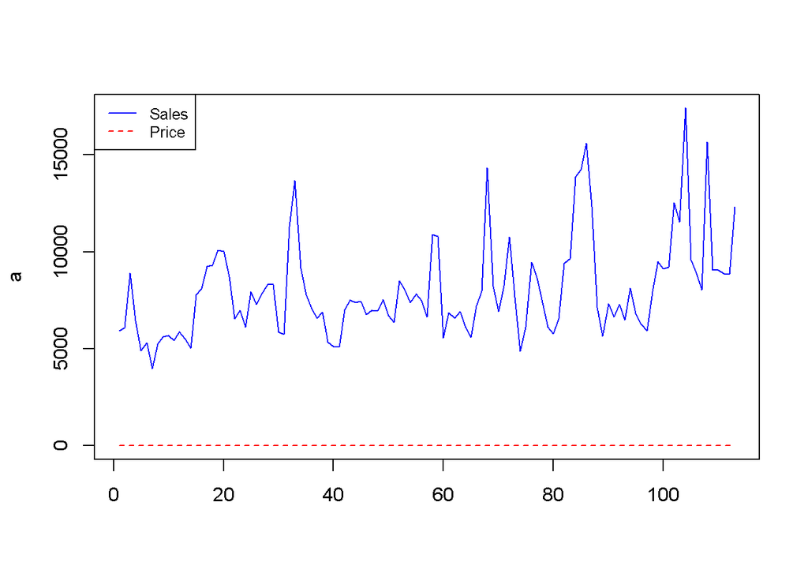

```r
matplot(a,pch=1:2,type="l",col=c("blue","red"))
legend('topleft',c("Sales","Price"),lty=1:2,col=c("blue","red"),cex=0.8)
```

For more information regarding the options used in this plotting command, please refer to the next session on **R Graphics**.

One issue for this plot is that the price variable can be barely seen. take a look at the two variables we can quickly notice that these two variables have very different scales.

```r
head(df)
```

```
##   weeknum Sales1  Price1    feat1
## 1       1   5929 4.29168  0.00000
## 2       2   6089 4.29168  0.00000
## 3       3   8909 4.29168 29.59473
## 4       4   6469 4.29168  0.00000
## 5       5   4917 4.29168  0.00000
## 6       6   5299 4.29168  0.00000
```

The sales variable is in the unit of thousand, but the price variable is much smaller. In order to see them together on the same plot, we need to rescale the variables, to make them into a similar scale, then replot them together.

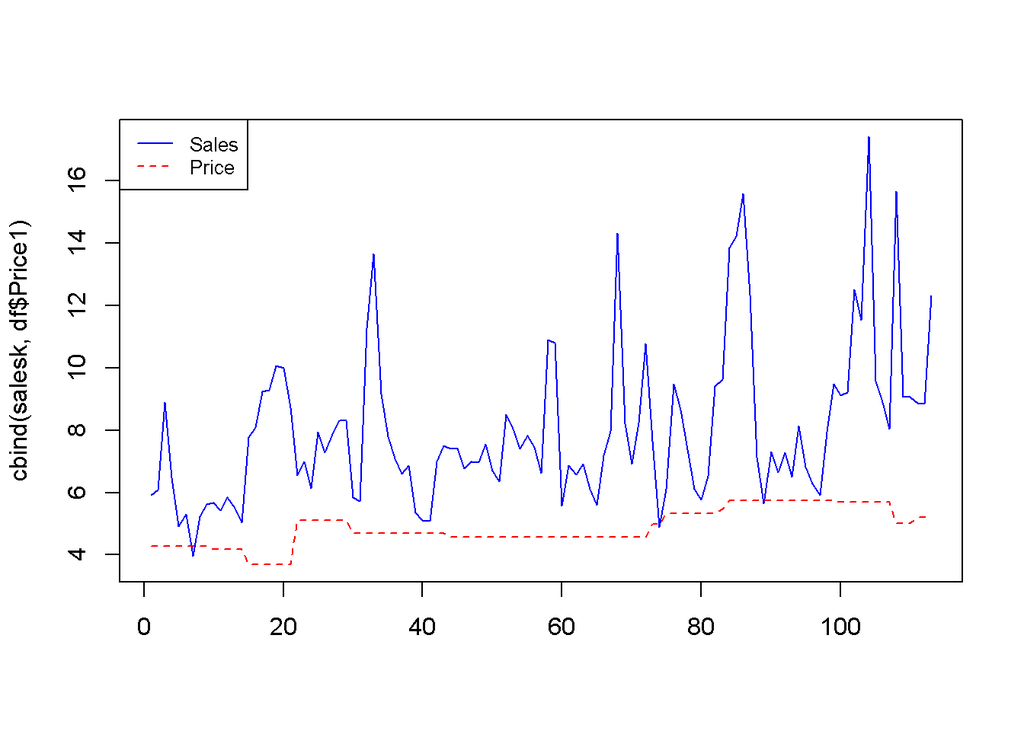

```r
salesk=df$Sales1/1000
matplot(cbind(salesk,df$Price1),pch=1:2,type="l",col=c("blue","red"))
legend('topleft',c("Sales","Price"),lty=1:2,col=c("blue","red"),cex=0.8)
```

> Q: What’s the relationship between price and sales, based on this plot?

As mentioned earlier, it is always a good idea to plot the data first, to get familiar with the data, before trying different models. This plot will provide you with a knowledgable expectation from a model with only price to explain the sales numbers: the fit will not be good.

> Q: what should we do?

Maybe consider adding some more variables into the model. To do that, first, let’s check what other variables we have in the data.

```r
colnames(df)
```

```
## [1] "weeknum" "Sales1"  "Price1"  "feat1"
```

or as we mentioned before, you can look at the first few rows in the dataframe using

```r
head(df)
```

```
##   weeknum Sales1  Price1    feat1
## 1       1   5929 4.29168  0.00000
## 2       2   6089 4.29168  0.00000
## 3       3   8909 4.29168 29.59473
## 4       4   6469 4.29168  0.00000
## 5       5   4917 4.29168  0.00000
## 6       6   5299 4.29168  0.00000
```

```r
lm2 = lm(df$Sales1~df$Price1+df$feat1)
summary(lm2)
```

```
##
## Call:
## lm(formula = df$Sales1 ~ df$Price1 + df$feat1)
##
## Residuals:
##     Min      1Q  Median      3Q     Max
## -4700.2 -1301.8   -97.1   934.9  6722.4
##
## Coefficients:
##             Estimate Std. Error t value Pr(>|t|)
## (Intercept) 1324.688   1644.890   0.805 0.422363
## df$Price1   1181.894    333.266   3.546 0.000575 ***
## df$feat1      50.552      8.016   6.306 6.12e-09 ***
## ---
## Signif. codes:  0 '***' 0.001 '**' 0.01 '*' 0.05 '.' 0.1 ' ' 1
##
## Residual standard error: 2080 on 110 degrees of freedom
## Multiple R-squared:  0.3221, Adjusted R-squared:  0.3098
## F-statistic: 26.14 on 2 and 110 DF,  p-value: 5.162e-10
```

If a result like this was submitted to the business manager, it would be returned or discarded.  
Before we think more ways of improving the model, let’s first spend some time to understand the assumptions required for a meaningful regression model, and see whether our exercise fits those assumptions (limitations) of a regression model.

### Assumptions in Regression Models

Like any statistical model, Regression model relies on a series of important assumptions. However, as Regression model is convenient and easy to use, these assumptions sometimes are ignored. In such situations, the interpretation of the model results are misleading.

To keep the notation consisten, the following discussions are all about a regression model like this:

$y_i=\beta_0+\beta_1X_{i1}+\beta_2X_{i2}...+\beta_kX_{ik}+\epsilon_i$ Among this, $i={1,2,...,N}$, and $N$ refers to the number of rows in the data.

It can be also written in a matrix format for simplicity $Y=X\beta+e$

In this specification, * $Y$ stands for a vector with dimension $(N,1)$.  
* $X$ stands for a matrix with dimension $(N,K+1)$ and $K$ refers to the number of X variables in the regression matrix. The first column in this matrix is a column of 1s, corresponding to the intercept in the model. * $\beta$ is a vector with $K+1$ elements, $\beta={\beta_0,\beta_1,...,\beta_K}$. * $e$ is a vector with the same dimension as $Y$, that is $(N,1)$

All the assumptions are required in setting up the regression model, there is no particular ordering among them.

#### Assumption 1: Error term distribution

The error terms $\epsilon_i$ are following the same distribution, and they are independent among one another. In other words, they are identically and independently distributed (IID).

There are two possible ways to violate this assumption: 1. **Auto-correlation**: The $\epsilon_i$’s are correlated among themselves. 2. **Heteroschedasticity** The $\epsilon_i$’s are not identically distributed.

##### **Auto-correlation**

In the first case, the error terms are correlated among themselves, and is often called auto-correlation. This happens more often among time series models, when the error term from $t-1$ is correlated with the error term from $t$, or $corr(\epsilon_t,\epsilon_{t-1})\ne0$.

One way to check whether auto-correlation exists is to calculate the correlations directly,

```r
errs = summary(lm1)$residuals
N = length(errs)
cor(errs[1:(N-1)],errs[2:N])
```

```
## [1] 0.5099619
```

The answer is 0.5099619, which seems to be really high. This is also called the *first-order* auto-correlation, as it says the error term is correlated with the one next to it. There are also more rigorous statistical test, such as Durbin Watson test for this purpose. You will learn more details about that in the Machine Learning class.

Now, you see such high first-order auto-correlation, what can you do about it in the modeling?

> Q: Let’s first think about what might lead to such higher first-order auto-correlation?

*One possible solution* is to include the sales number from last time period, that is so far we estimated the model

$sales_t=\beta_0+\beta_1Price_t+\beta_2Promotion_t+\epsilon_t$

Now, we can consider adding another variable to the right hand side, called $sales_{t-1}$, that is $Sales_t=\beta_0+\beta_1Price_t+\beta_2Promotion_t+\beta_3Sales_{t-1}+\epsilon_t$

```r
Xmat=cbind(df$Price1[2:N], df$feat1[2:N], df$Sales1[1:(N-1)])
y = df$Sales1[2:N]
lmlag = lm(y~Xmat)
summary(lmlag)
```

```
##
## Call:
## lm(formula = y ~ Xmat)
##
## Residuals:
##     Min      1Q  Median      3Q     Max
## -3883.1 -1019.7  -179.7   746.9  6023.0
##
## Coefficients:
##              Estimate Std. Error t value Pr(>|t|)
## (Intercept) 7.796e+02  1.480e+03   0.527   0.5993
## Xmat1       6.436e+02  3.137e+02   2.052   0.0426 *
## Xmat2       3.929e+01  7.445e+00   5.277 6.84e-07 ***
## Xmat3       4.248e-01  7.716e-02   5.505 2.51e-07 ***
## ---
## Signif. codes:  0 '***' 0.001 '**' 0.01 '*' 0.05 '.' 0.1 ' ' 1
##
## Residual standard error: 1854 on 108 degrees of freedom
## Multiple R-squared:  0.4676, Adjusted R-squared:  0.4528
## F-statistic: 31.62 on 3 and 108 DF,  p-value: 9.491e-15
```

##### **Heteroschedasticity**

In the second case, it also requires the error terms ${\epsilon_i}$ to follow the same distribution. As the error terms all have the same mean 0, this requirement means that they also need to have the same variance.

To check whether all the residuals do share the same variance, the simplest way is to plot them:

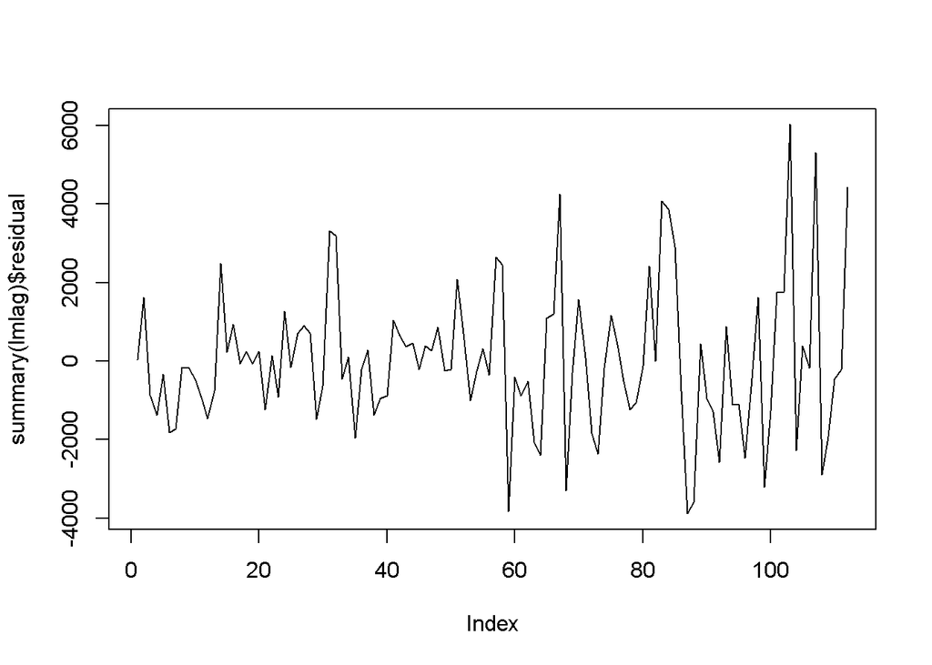

```r
plot(summary(lmlag)$residual,type="l")
```

For example, if each data points represent different level of aggregation. One such scenario happens when we look at the store level sales from many different stores by the same chain. These stores maybe different in terms of the size of the population they served. Think about the various Starbucks stores across regions. The data are generated by different population size, and hence the data at each store are in different scale, and hence may lead to heteroschedasticity issue in the error term. The solution is to rescale the data by dividing a measure of population size served by each store. Then run the regression analysis using the resaled data.

In another example, if you find that the $var(\epsilon)$ looks very different when the $X$ values are larger than when the $X$ values are smaller, you could consider a nonlinear transformation of the $X$ variable, to shrink range of the $X$ values.

> Q: what would be an easy non-linear transformation to shrink the range of $X$ values?

#### Assumption 2: The error terms are uncorrelated with the $X$ variables.

This turns out to be the most important assumption in estimating regression model in Marketing Analytics, however, it is often neglected. The reason that it may be neglected is most data analysts focus on the statistical tools, rather than the Data Generating Process. It is important to think through what is really captured in the ${\epsilon_i}$. Very often, due to data collection limitations, we can not get all the data we need for the model we have. Those information that we do not have is then all dumped into the error terms.

Then the question is how do we know what’s captured in the ${\epsilon_i}$. To have a good understanding of that, the analyst needs to think from the customer’s perspective, and see how the decision described in the $Y$ varaible is made. In our example, the decision is to purchase coffee. What’s the scenario in this data set? What’s the Data Generating Process in our example? These shoudl be the first question to ask whenever you try to conduct some analysis for any business decision.

Our data is actually from a grocery store. One brand of coffee, call it CoffeeA, asked the grocery store for the price and sales data of its product in the store. So, the manager at CoffeeA company wants to analyze how price influences its sales in this store.

> Q: In this setup, imagine you are a customer in the store, looking at the shelf of the coffee category. What might be the factors that would influence your decision on whether to purchase CoffeeA?

One very important factor that’s missing here is the other brands’ price. In a grocery store setup, the customers would find different brands next to each other, together with their prices. So, the competitors’ price is an important factor influencing the customer’s decision of whether to purchase CoffeeA. If it is not in the data, then it is captured by the $\epsilon$ term.

There are so many factors captured in the $\epsilon$ term, why the competitor’s price would cause trouble? This is due to the way to set the prices. Here, institutional (marketing) knowledge is critical. In retail management, prices are generally set by *Category Managers*, where the different brands, although from different companies, are set by one person (group). In that case, the prices of the various brands could be highly correlated, meaning they are increased or decreased together.

Imagine there are only two brands CoffeeA and CoffeeB in the store. If CoffeeA’s price is raised, in the mean time, CoffeeB’s price is also increased, and increased even more than CoffeeA. If you are a consumer who really cares about price, which brand are you going to purchase? Most likely it is CoffeeA. However, we have data only about CoffeeA, its price and sales. From such data, we see that CoffeeA’s price is increased, in the mean time, its sales are increased as well. Hence, we got the parameter estimate to be positive for the price variable.

The main issue is that there is some factor left with the error term ${\epsilon_i}$, and made the error term to be correlated with an $X$ variable. In that case, the parameter estimate for this $X$ variable is *biased*.

This is called the **Endogeneity** issue.

##### **Endogeneity**

One of the main reason that the endogeneity issue is commonly ignored in the data anlytics exercise, is because this is not a statistical problem. If it was, some statistician will develop a statistical test for it, but this one is not.

> Q: Can you calculate the error terms and then calculate $cor(\epsilon,X)$ to detect the existence of Endogeneity issue?

The answer is NO. Before you can calculate the values of the ${\epsilon_i}$, you need to estimate the model. If the model suffers from the endogeneity issue, you’ve got the wrong estimate and the wrong error term values. Then the question is when does this issue exist?

The answer to that question is very simple: It always exists when you analyze human-generated data.

This is simply because human being is too complex to be able to capture fully the decision process, therefore, many factors are left with the error term. To help you understand the situation, I’ve summarized three scenarios for endogeneity issue to exist in Marketing Analytics.

**First, omitted variable bias**

In a regression model, if the error term captures some factors that influence the $Y$ value but also correlated with an $X$ variable, it will cause bias to the parameter estimate for this $X$ variable. The example we mentioned above fits this situation.

**Second, correlation vs. causation**

As discussed earlier, regression results only capture correlations, not causations. If there is a common factor that influences both the values of $Y$ and an $X$ variable, it will leads to highly significant estimate on the parameter, but incorrect. For example, right before Thanksgiving, many people buy turkey, and in the meantime, many grocery store lower turkey’s price to drive the traffice. Using those data, you will exaggerate the price effect on turkey sales. Many of those incremental sales is not driven by the lowered price, but actually by the thanksgiving holiday!

**Third, reverse causation**

Recall the interpretation of the parameter estimates meansure the marginal impact of $X$ on $Y$, holding everything else constant. However, sometimes, the data generation process is such that the $X$ value is determined by the $Y$ value. This is really common in marketing. Think about a retailer, when choosing who to send coupons to. A smart company would send only coupon to the customers who the company believe are likely to make a purchase. Otherwise, coupon and mailing cost are completely wasted. When a customer receives the coupon, he was in the store for a small purchase, he may decide not to use the coupon, as he knows that in the weekend he would make a bigger purchase, and will benefit more from the coupon. From the data, what we would see are (1) customers who used coupon tend to buy more than those who do not use coupon; and (2) even within a customer, he would buy more when he uses coupon than when he does not. So the results interpretation are completely reversed the causation as in the data generation process.

##### **Solution to the Endogeneity Problem**

The reason that endogeneity issue appeared in our example is due to the combination of the following two results: 1. competitor’s price is left in the error term, 2. the competitor’s price is correlated with the own price Due to the above two reasons, the model suffers from $cor(Price,\epsilon)\ne0$. To solve this problem, we need to get rid of this correlation. One way we can do this is to decomponse the $Price$ variable into two components: one component has no correlations with the error term, and the other component captures all the correlation with the error term or the competitor’s price. To do that we can run a regression model

$Price=\alpha_0+\alpha_1Cost+\eta$

Suppose the cost for CoffeeA has nothing to do with its competitor’s coffee price, all the correlation is captured by the error term in this regression $\eta$. What we can do is to get rid of the “dirty part” of the $Price$ variable by throwing out the $\eta$.

To Do that, we can estimate this price~cost regression first, obtained the model estimates $\hat{\alpha_0},\hat{\alpha_1}$, plug these values into the model, and get the calculated price, that is

$\hat{Price}=\hat{\alpha_0}+\hat{\alpha_1}Cost$

The only difference between $Price$ and $\hat{Price}$ is the “dirty part” $\eta$. Now, $\hat{Price}$ is cleaned up, with no correlations with $\epsilon$, we can put it into the first regression, and obtain the correct estimate for its parameter.

> Q: Why we do not put the $Cost$ variable to take the place of the $Price$ variable in the original regression on sales?